# R Notebook

This tutorial is to show how pooling affects estimation.

First, I got the estimates:

```r
.libPaths()
```

```
## [1] "C:/Users/yymathe/Documents/R/win-library/3.3"
## [2] "C:/R/R-3.3.2/library"
```

```r
library(pacman)
p_load(tidyverse, rethinking)

# p_delete(rethinking)
p_load_gh("rmcelreath/rethinking")

library("rethinking")
```

Code below creates pre- and post-intervention wear times for 60 classes of different size. Naturally the smaller classes end up with more variation.

```r
mean_val <- 4500/60 # 75; approximate values from the data, converted to hours
sd_val <- 1600/60 # 26.6667
mean_val
```

```
## [1] 75
```

```r
sd_val
```

```
## [1] 26.66667
```

```r
nclasses <- 60

n_students <- rep(c(6, 15, 25, 40), each = 15) %>% as.integer()
n_students
```

```
##  [1]  6  6  6  6  6  6  6  6  6  6  6  6  6  6  6 15 15 15 15 15 15 15 15
## [24] 15 15 15 15 15 15 15 25 25 25 25 25 25 25 25 25 25 25 25 25 25 25 40
## [47] 40 40 40 40 40 40 40 40 40 40 40 40 40 40
```

```r
# for a more noticeable effect, try more dramatic numbers:
# n_students <- rep(c(1, 1, 1e5, 1e5), each = 15) %>% as.integer()

# Create an empty vector for the class means
mean_class_pre <- rep(NA, 60)
mean_class_post <- rep(NA, 60)

set.seed(1)
for (i in 1:nclasses) { # Loop around each class size
simd_pre <- rnorm(n_students[i], mean = mean_val, sd = sd_val) # Create random values according to class size
simd_post <- rnorm(n_students[i], mean = simd_pre + sd_val * 0.3, sd = sd_val) # add a d=0.3 change
mean_class_pre[i] <- mean(simd_pre) # Calculate mean of the random numbers and store it to a vector
mean_class_post[i] <- mean(simd_post)
}

# Here are the simulated class means:
mean_class_pre
```

```
##  [1] 74.22614 71.31868 70.00862 79.40761 73.96266 86.22506 67.32113
##  [8] 85.32413 56.66168 82.78029 79.69076 61.46202 63.04852 79.66702
## [15] 87.69673 70.24471 68.19115 77.17688 77.32431 83.08166 69.55323
## [22] 66.53621 85.04706 65.83901 71.71569 82.06604 66.19682 75.10386
## [29] 82.18847 80.06780 64.33417 71.61447 71.25863 70.21327 78.23862
## [36] 75.22011 81.82649 75.41638 82.78323 80.52274 71.06271 73.71973
## [43] 75.56032 90.03619 67.98809 73.07157 73.18226 75.42234 71.84026
## [50] 76.34594 73.91029 71.75087 73.37176 71.74943 74.18912 71.86895
## [57] 74.59177 80.13624 71.42769 64.84936
```

```r
# Here are the simulated changes in class means:
mean_class_post
```

```
##  [1]  97.32734  84.65845  77.10953  91.80979  92.79258 102.01183  68.36777
##  [8] 114.08540  73.49142  86.85835  80.37581  53.57193  56.03316  95.89921
## [15] 116.71655  86.56419  70.30677  84.30169  90.29531  94.60993  83.02114
## [22]  73.26888  95.50857  66.97876  84.08999  85.05819  78.70027  75.91775
## [29]  87.14843  87.34889  62.52666  80.70692  83.98469  77.72266  85.38941
## [36]  86.85069  82.80711  75.25222  83.34428  79.01892  73.91593  92.92325
## [43]  86.85629  94.07714  70.79418  87.86378  84.11042  80.04700  75.39661
## [50]  82.31765  89.97838  75.32413  80.36234  75.34775  85.31743  82.21248
## [57]  84.91457  92.67712  82.36320  70.23037
```

```r
# Collect everything to a data frame
dsim <- data.frame(classroom = 1:nclasses, n_students = n_students, true_mean_pre = mean_class_pre, true_mean_post = mean_class_post)
dsim
```

```
##    classroom n_students true_mean_pre true_mean_post
## 1          1          6      74.22614       97.32734
## 2          2          6      71.31868       84.65845
## 3          3          6      70.00862       77.10953
## 4          4          6      79.40761       91.80979
## 5          5          6      73.96266       92.79258
## 6          6          6      86.22506      102.01183
## 7          7          6      67.32113       68.36777
## 8          8          6      85.32413      114.08540
## 9          9          6      56.66168       73.49142
## 10        10          6      82.78029       86.85835
## 11        11          6      79.69076       80.37581
## 12        12          6      61.46202       53.57193
## 13        13          6      63.04852       56.03316
## 14        14          6      79.66702       95.89921
```

[output cut: 46 more lines]

We calculated the change so that if we had an infinite sample, we’d observe the true change of 8 hours (0.3 * 26.6667).

**Data analysis begins!**

Estimates without pooling:

```r
dsim$meanchange_nopool <- dsim$true_mean_post - dsim$true_mean_pre
dsim$meanchange_nopool
```

```
##  [1] 23.1012050 13.3397754  7.1009079 12.4021805 18.8299223 15.7867748
##  [7]  1.0466366 28.7612619 16.8297398  4.0780578  0.6850517 -7.8900912
## [13] -7.0153594 16.2321930 29.0198159 16.3194821  2.1156217  7.1248102
## [19] 12.9709978 11.5282753 13.4679099  6.7326712 10.4615084  1.1397533
## [25] 12.3742977  2.9921505 12.5034471  0.8138907  4.9599655  7.2810950
## [31] -1.8075150  9.0924577 12.7260567  7.5093929  7.1507973 11.6305831
## [37]  0.9806142 -0.1641561  0.5610577 -1.5038173  2.8532216 19.2035198
## [43] 11.2959692  4.0409500  2.8060861 14.7922113 10.9281606  4.6246608
## [49]  3.5563497  5.9717049 16.0680830  3.5732664  6.9905742  3.5983263
## [55] 11.1283090 10.3435388 10.3227978 12.5408798 10.9355091  5.3810066
```

```r
dsim$true_mean_pre
```

```
##  [1] 74.22614 71.31868 70.00862 79.40761 73.96266 86.22506 67.32113
##  [8] 85.32413 56.66168 82.78029 79.69076 61.46202 63.04852 79.66702
## [15] 87.69673 70.24471 68.19115 77.17688 77.32431 83.08166 69.55323
## [22] 66.53621 85.04706 65.83901 71.71569 82.06604 66.19682 75.10386
## [29] 82.18847 80.06780 64.33417 71.61447 71.25863 70.21327 78.23862
## [36] 75.22011 81.82649 75.41638 82.78323 80.52274 71.06271 73.71973
## [43] 75.56032 90.03619 67.98809 73.07157 73.18226 75.42234 71.84026
## [50] 76.34594 73.91029 71.75087 73.37176 71.74943 74.18912 71.86895
## [57] 74.59177 80.13624 71.42769 64.84936
```

Here are the mean changes for each class size; you can see how smaller classes have more variability, which means more uncertainty and wider confidence intervals.

```r
dsim %>%
  dplyr::group_by(n_students) %>%
  dplyr::mutate(class_mean = mean(meanchange_nopool)) %>%
  dplyr::summarise(mean_change = mean(meanchange_nopool),
                   sd_change = sd(meanchange_nopool),
                   n = n()) %>%
  dplyr::mutate(std_err = sd_change / sqrt(n),
                lower_ci = mean_change - qt(1 - (0.05/2), n - 1) * std_err,
                upper_ci = mean_change + qt(1 - (0.05/2), n - 1) * std_err) %>%
  dplyr::select(n_students, mean_change, lower_ci, upper_ci)
```

```
## # A tibble: 4 × 4
##   n_students mean_change lower_ci  upper_ci
##        <int>       <dbl>    <dbl>     <dbl>
## 1          6   11.487205 5.059571 17.914839
## 2         15    8.185725 5.409837 10.961613
## 3         25    5.758348 2.365230  9.151466
## 4         40    8.717025 6.404637 11.029414
```

Let’s “tidy” the dataset, i.e. transform it to long form, where each class has one row with pre-intervention value and one row with post-intervention value. The variable “post” gets value 1 for post-intervention rows and zero otherwise.

```r
dsim_tidy <- dsim %>%
  tidyr::gather(time, value, true_mean_pre, true_mean_post) %>%
  dplyr::mutate(post = ifelse(time == "true_mean_pre", 0, 1),
                classf = as.factor(classroom))

dsim_tidy
```

```
##     classroom n_students meanchange_nopool           time     value post
## 1           1          6        23.1012050  true_mean_pre  74.22614    0
## 2           2          6        13.3397754  true_mean_pre  71.31868    0
## 3           3          6         7.1009079  true_mean_pre  70.00862    0
## 4           4          6        12.4021805  true_mean_pre  79.40761    0
## 5           5          6        18.8299223  true_mean_pre  73.96266    0
## 6           6          6        15.7867748  true_mean_pre  86.22506    0
## 7           7          6         1.0466366  true_mean_pre  67.32113    0
## 8           8          6        28.7612619  true_mean_pre  85.32413    0
## 9           9          6        16.8297398  true_mean_pre  56.66168    0
## 10         10          6         4.0780578  true_mean_pre  82.78029    0
## 11         11          6         0.6850517  true_mean_pre  79.69076    0
## 12         12          6        -7.8900912  true_mean_pre  61.46202    0
## 13         13          6        -7.0153594  true_mean_pre  63.04852    0
## 14         14          6        16.2321930  true_mean_pre  79.66702    0
```

[output cut: 227 more lines]

Here’s a simple linear regression on the form:

```r
ols_mod <- lm(value ~ post, data = dsim_tidy)
summary(ols_mod)
```

```
##
## Call:
## lm(formula = value ~ post, data = dsim_tidy)
##
## Residuals:
##     Min      1Q  Median      3Q     Max
## -29.409  -4.549  -0.196   5.029  33.736
##
## Coefficients:
##             Estimate Std. Error t value Pr(>|t|)
## (Intercept)   74.444      1.201  62.010  < 2e-16 ***
## post           8.537      1.698   5.028 1.78e-06 ***
## ---
## Signif. codes:  0 '***' 0.001 '**' 0.01 '*' 0.05 '.' 0.1 ' ' 1
##
## Residual standard error: 9.299 on 118 degrees of freedom
## Multiple R-squared:  0.1765, Adjusted R-squared:  0.1695
## F-statistic: 25.28 on 1 and 118 DF,  p-value: 1.785e-06
```

The value of “post” is now 8.54, slightly exaggerated from the real value. Let’s add class as a dummy variable:

```r
ols_mod <- lm(value ~ post + classf, data = dsim_tidy)
broom::tidy(ols_mod) %>% filter(term == "post")
```

```
##   term estimate std.error statistic      p.value
## 1 post 8.537076 0.9590807  8.901311 1.668896e-12
```

When we added class, the estimate remained the same but it’s standard error came down. MCMC gives nearly the same solution

```r
mnopool <- rethinking::map2stan(
  alist(
    value ~ dnorm(mu, sigma),
    mu <- a + bp * post,
    a ~ dnorm(0, 100),
    bp ~ dnorm(0, 100),
    sigma ~ dcauchy(0, 100)),
    data = dsim_tidy,
    iter = 4000,
    chains = 2,
    warmup = 1000
)
```

[output not shown]

[output cut: 61 more lines]

[output not shown]

```
## Computing WAIC
```

```
## Constructing posterior predictions
```

[output not shown]

```r
precis(mnopool, prob = 0.95)
```

```
##        Mean StdDev lower 0.95 upper 0.95 n_eff Rhat
## a     74.43   1.23      72.06      76.86  2825    1
## bp     8.57   1.76       5.06      11.97  2688    1
## sigma  9.39   0.62       8.16      10.59  3918    1
```

```r
mpartpool <- rethinking::map2stan(
  alist(
    value ~ dnorm(mu, sigma),
    mu <- a[classroom] + bp * post,
    a[classroom] ~ dnorm(0, 100),
    bp ~ dnorm(0, 100),
    sigma ~ dcauchy(0, 100)),
    data = dsim_tidy,
    iter = 4000,
    chains = 2,
    warmup = 1000
)
```

[output not shown]

[output cut: 39 more lines]

[output not shown]

[output not shown]

```
## Computing WAIC
```

```
## Constructing posterior predictions
```

[output not shown]

```r
precis(mpartpool, depth = 2, prob = 0.95)
```

```
##        Mean StdDev lower 0.95 upper 0.95 n_eff Rhat
## a[1]  81.23   3.79      73.60      88.33  6000    1
## a[2]  73.57   3.83      66.25      81.16  6000    1
## a[3]  69.05   3.82      61.65      76.57  6000    1
## a[4]  81.10   3.81      73.68      88.62  6000    1
## a[5]  78.81   3.91      71.43      86.77  6000    1
## a[6]  89.59   3.95      81.68      97.42  6000    1
## a[7]  63.45   3.89      55.95      71.22  6000    1
## a[8]  95.20   3.87      87.77     102.98  6000    1
## a[9]  60.51   3.81      53.09      67.81  6000    1
## a[10] 80.38   3.86      73.05      88.33  6000    1
## a[11] 75.53   3.89      67.74      83.06  6000    1
## a[12] 53.01   3.87      45.35      60.56  6000    1
## a[13] 55.06   3.88      47.44      62.54  6000    1
## a[14] 83.21   3.81      75.93      90.85  6000    1
## a[15] 97.64   3.83      90.25     105.06  6000    1
## a[16] 73.90   3.81      66.90      81.90  6000    1
## a[17] 64.77   3.81      57.20      71.84  6000    1
## a[18] 76.27   3.82      68.74      83.76  6000    1
## a[19] 79.31   3.95      71.20      86.64  6000    1
## a[20] 84.36   3.85      77.04      91.83  6000    1
## a[21] 71.87   3.88      64.46      79.60  6000    1
## a[22] 65.47   3.91      57.49      72.81  6000    1
## a[23] 85.76   3.87      78.19      93.61  6000    1
## a[24] 61.98   3.84      54.09      69.21  6000    1
## a[25] 73.37   3.81      65.81      80.55  6000    1
## a[26] 79.05   3.82      71.62      86.52  6000    1
## a[27] 67.94   3.77      60.49      75.18  6000    1
## a[28] 71.03   3.92      63.79      79.00  6000    1
## a[29] 80.15   3.81      72.48      87.18  6000    1
## a[30] 79.18   3.83      71.73      86.78  6000    1
## a[31] 58.99   3.72      51.82      66.31  6000    1
## a[32] 71.71   3.80      64.41      79.36  6000    1
## a[33] 73.10   3.82      66.02      80.95  6000    1
## a[34] 69.48   3.77      62.13      76.77  6000    1
## a[35] 77.34   3.76      69.84      84.61  6000    1
## a[36] 76.55   3.90      68.80      83.86  6000    1
## a[37] 77.83   3.83      70.47      85.42  6000    1
## a[38] 70.85   3.84      63.31      78.37  6000    1
## a[39] 78.54   3.76      70.70      85.44  6000    1
```

[output cut: 8 more lines]

```
## a[48] 73.24   3.88      66.00      81.42  6000    1
## a[49] 69.19   3.86      61.63      76.97  6000    1
## a[50] 74.83   3.71      67.43      81.95  6000    1
## a[51] 77.46   3.88      69.63      84.78  6000    1
## a[52] 68.98   3.75      61.63      76.29  6000    1
## a[53] 72.33   3.92      64.87      80.13  6000    1
## a[54] 69.05   3.94      61.34      76.65  6000    1
## a[55] 75.24   3.91      67.58      82.79  6000    1
## a[56] 72.54   3.79      65.41      80.16  6000    1
## a[57] 75.22   3.95      67.63      83.08  6000    1
## a[58] 81.85   3.81      74.47      89.24  6000    1
## a[59] 72.45   3.90      64.88      80.12  6000    1
## a[60] 63.08   3.89      55.32      70.44  6000    1
## bp     8.77   0.97       6.76      10.61  4713    1
## sigma  5.37   0.51       4.46       6.39  2307    1
```

```r
mpartpool2 <- rethinking::map2stan(
  alist(
    value ~ dnorm(mu, sigma),
    mu <- a[classroom] + bp[classroom] * post,
    a[classroom] ~ dnorm(0, 100),
    bp[classroom] ~ dnorm(0, 100),
    sigma ~ dcauchy(0, 100)),
    data = dsim_tidy,
    iter = 20000,
    chains = 2,
    warmup = 5000
)
```

[output not shown]

[output cut: 45 more lines]

[output not shown]

[output not shown]

```
## Computing WAIC
```

```
## Constructing posterior predictions
```

[output not shown]

```r
precis(mpartpool2, depth = 2, prob = 0.95)
```

```
##         Mean StdDev lower 0.95 upper 0.95 n_eff Rhat
## a[1]   73.73   9.14      54.19      93.44 30000 1.00
## a[2]   70.82   9.27      51.30      91.02 30000 1.00
## a[3]   69.52   9.17      49.66      89.26 30000 1.00
## a[4]   78.85   9.12      59.95      98.70 30000 1.00
## a[5]   73.50   9.22      53.25      92.78 30000 1.00
## a[6]   85.68   9.29      66.09     105.66 30000 1.00
## a[7]   66.85   9.20      46.90      86.13 30000 1.00
## a[8]   84.86   9.25      64.41     104.07 30000 1.00
## a[9]   56.34   9.17      36.83      76.06 30000 1.00
## a[10]  82.09   9.41      61.69     101.64 30000 1.00
## a[11]  79.10   9.19      59.04      98.32 30000 1.00
## a[12]  60.89   9.15      41.42      80.55 30000 1.00
## a[13]  62.42   9.12      41.62      80.88 30000 1.00
## a[14]  79.17   9.26      58.73      98.61 30000 1.00
## a[15]  87.22   9.22      66.82     106.33 30000 1.00
## a[16]  69.71   9.29      50.16      90.02 30000 1.00
## a[17]  67.60   9.30      47.40      87.01 30000 1.00
## a[18]  76.61   9.21      57.33      96.44 30000 1.00
## a[19]  76.76   9.25      57.41      96.99 30000 1.00
## a[20]  82.46   9.48      60.90     101.55 30000 1.00
## a[21]  69.04   9.19      49.01      88.27 30000 1.00
## a[22]  66.11   9.24      46.29      85.87 30000 1.00
## a[23]  84.39   9.34      63.92     103.57 30000 1.00
## a[24]  65.30   9.14      45.60      84.54 30000 1.00
## a[25]  71.23   9.00      51.47      90.25 30000 1.00
## a[26]  81.37   9.24      62.11     101.60 30000 1.00
## a[27]  65.75   9.14      46.19      85.09 30000 1.00
## a[28]  74.45   9.23      55.43      94.73 30000 1.00
## a[29]  81.46   9.23      62.33     101.87 30000 1.00
## a[30]  79.45   9.30      59.19      99.14 30000 1.00
## a[31]  63.75   9.30      43.87      83.21 30000 1.00
## a[32]  71.09   9.11      51.03      89.90 30000 1.00
## a[33]  70.82   9.31      51.14      90.70 30000 1.00
## a[34]  69.65   9.32      48.75      88.41 30000 1.00
## a[35]  77.67   9.28      56.53      96.41 30000 1.00
## a[36]  74.69   9.13      54.84      93.72 30000 1.00
## a[37]  81.11   9.31      61.58     100.71 30000 1.00
## a[38]  74.83   9.23      53.99      93.43 30000 1.00
## a[39]  82.08   9.28      61.82     101.46 30000 1.00
```

[output cut: 67 more lines]

```
## bp[47] 11.39  13.07     -17.67      38.55 30000 1.00
## bp[48]  5.18  13.02     -22.89      32.80 30000 1.00
## bp[49]  3.95  12.79     -23.35      31.30 30000 1.00
## bp[50]  6.45  12.92     -20.36      34.70 30000 1.00
## bp[51] 16.55  13.09     -11.41      44.56 30000 1.00
## bp[52]  4.13  13.17     -22.78      33.70 30000 1.00
## bp[53]  7.47  12.94     -19.61      35.06 30000 1.00
## bp[54]  4.21  13.02     -22.77      32.32 30000 1.00
## bp[55] 11.69  13.03     -15.56      40.51 30000 1.00
## bp[56] 10.74  13.02     -17.67      37.96 30000 1.00
## bp[57] 10.77  12.89     -15.80      38.78 30000 1.00
## bp[58] 13.13  12.96     -14.46      41.25 30000 1.00
## bp[59] 11.37  12.82     -15.16      40.15 30000 1.00
## bp[60]  5.86  12.77     -21.24      33.21 30000 1.00
## sigma   7.85   5.17       0.80      17.84   191 1.01
```

```
## Waiting to draw page 2 of 9
```

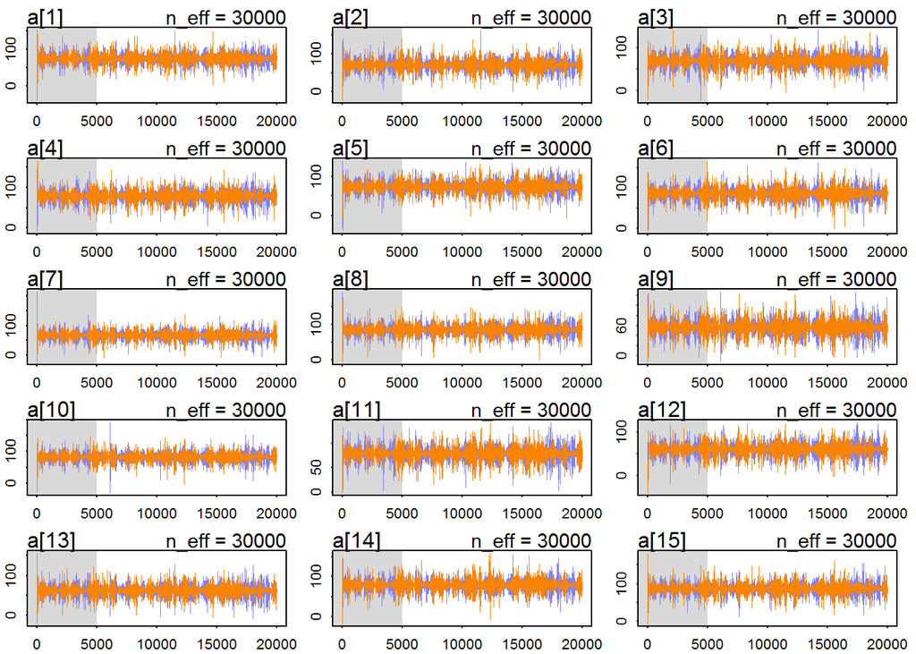

```
## Waiting to draw page 3 of 9
```

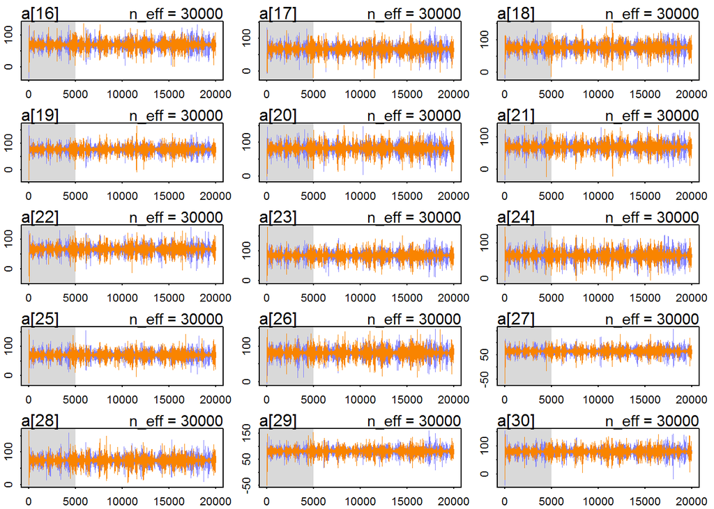

```
## Waiting to draw page 4 of 9
```

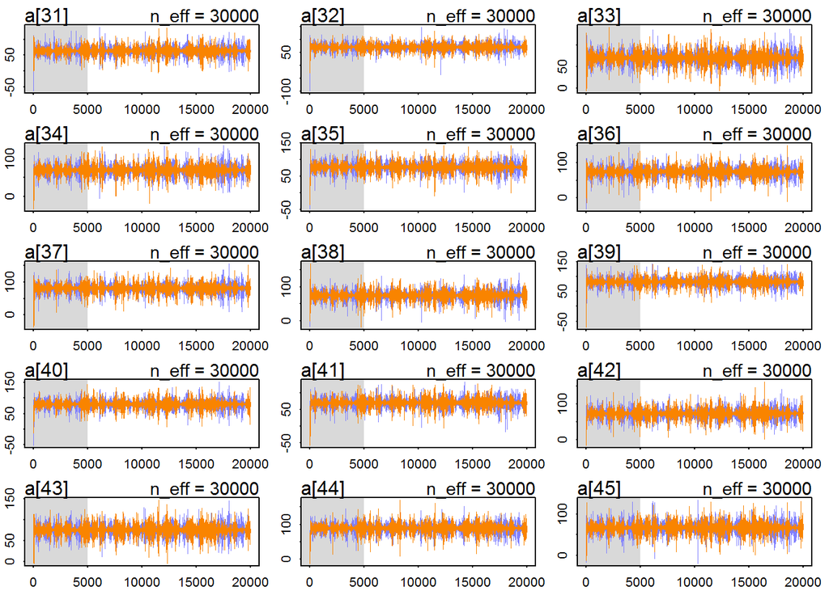

```
## Waiting to draw page 5 of 9
```

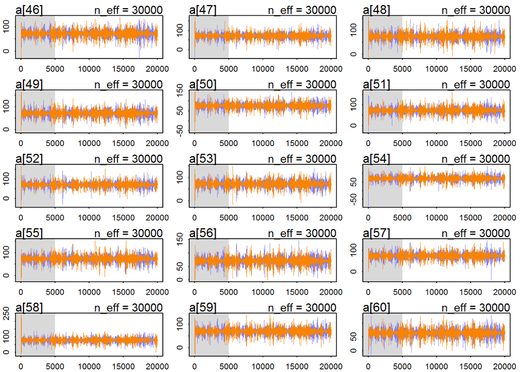

```
## Waiting to draw page 6 of 9
```

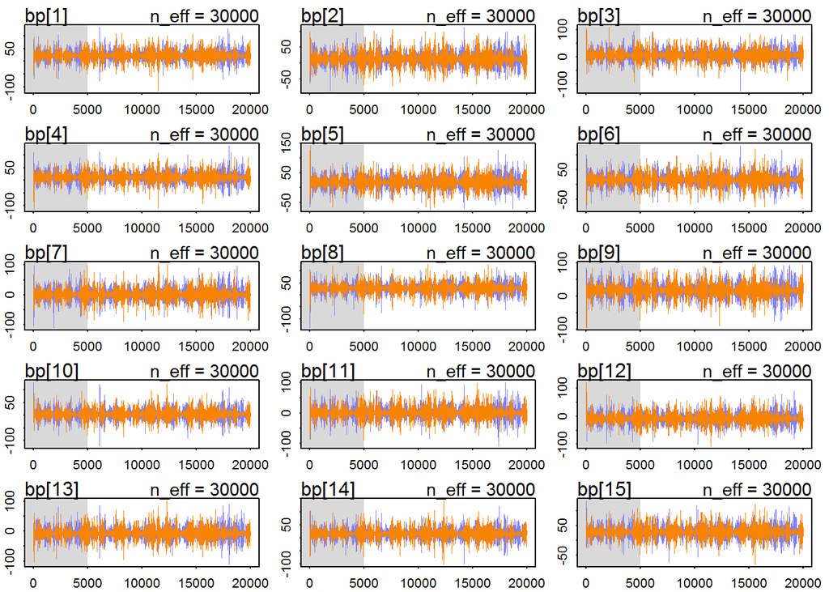

```
## Waiting to draw page 7 of 9
```

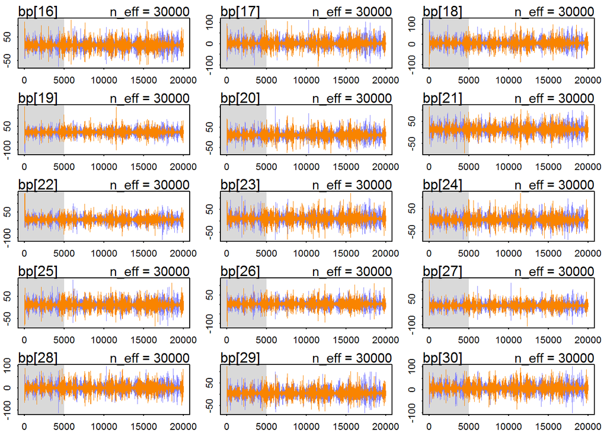

```
## Waiting to draw page 8 of 9
```

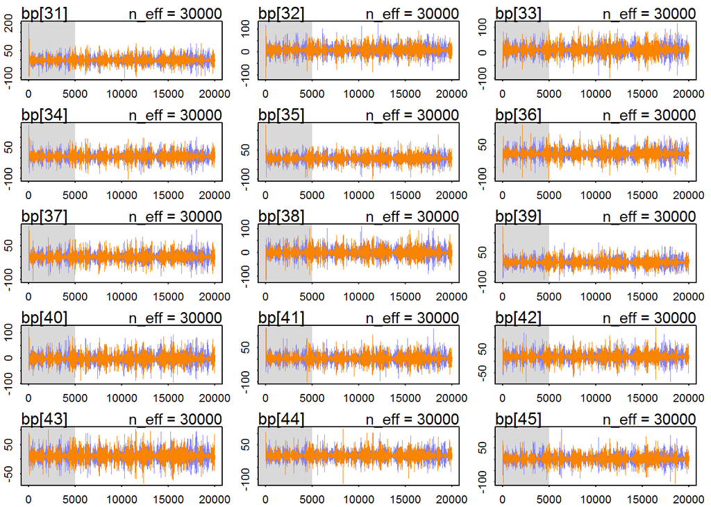

```
## Waiting to draw page 9 of 9
```

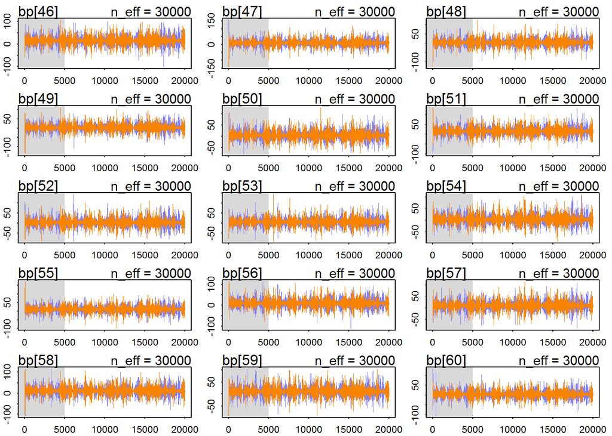

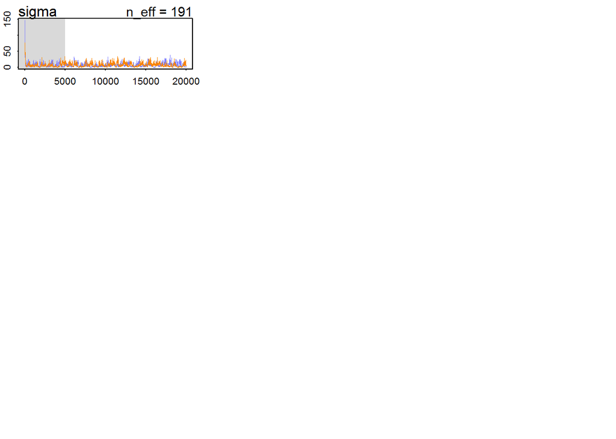

```r
mpartpool2 %>% tracerplot
```